# Imputing variables and estimateing ERGM for bushfire data

[Johan Koskinen](https://psychologicalsciences.unimelb.edu.au/research/msps-research-groups/Social_Networks_Laboratory)

2020-08-12

# Reading in bushfire data and perfomring imputations

The tabs of the master excel sheet have been saved as individual `.csv` files. Throughout it is assumed that you have set your current working director to where these files are using `setwd()`. All output will also be written to this directory

### Reading in data

Read in the data

```r
MT_attr <- read.csv('MT_attr.csv', stringsAsFactors=FALSE) # attributes; 'stringsAsFactors=FALSE' prevents R from interpreting strings as factors
MT_t1 <- read.csv('MT_t1.csv', stringsAsFactors=FALSE, header=FALSE) # ties at time 1
HHID <- read.csv('HHID.csv', stringsAsFactors=FALSE, header=TRUE) # household identifiers
```

It is a good idea to inspect the first six rows of the data matrices using

```r
head(MT_attr) # output is supressed here for data protection reasons
```

Quick summaries for data tells us the range of data and other descriptives

```r
summary(MT_attr)
```

```
##      SRCID         CLOSERHF_T1_REFUSE CLOSERHF_T2_REFUSE   RS3b_pcode
##  Min.   :   4417   Min.   :0.000      Min.   :0.00       Min.   : 999
##  1st Qu.:   6502   1st Qu.:0.000      1st Qu.:0.00       1st Qu.: 999
##  Median : 103140   Median :9.000      Median :9.00       Median : 999
##  Mean   : 637031   Mean   :4.611      Mean   :4.87       Mean   :2352
##  3rd Qu.: 134160   3rd Qu.:9.000      3rd Qu.:9.00       3rd Qu.:3714
##  Max.   :9002865   Max.   :9.000      Max.   :9.00       Max.   :3844
##    Present_T2         agebs0           sexM0          TERTIARY_ED
##  Min.   :0.0000   Min.   :  0.00   Min.   :  0.000   Min.   :  0.0
##  1st Qu.:0.0000   1st Qu.: 48.00   1st Qu.:  0.000   1st Qu.:  0.0
##  Median :0.0000   Median : 55.00   Median :  1.000   Median :999.0
##  Mean   :0.3568   Mean   : 73.95   Mean   :  8.654   Mean   :505.1
##  3rd Qu.:1.0000   3rd Qu.: 63.00   3rd Qu.:  1.000   3rd Qu.:999.0
##  Max.   :1.0000   Max.   :999.00   Max.   :999.000   Max.   :999.0
##    A7_retired    A7_employedFT        fear         personloss
##  Min.   :  0.0   Min.   :  0.0   Min.   :  0.0   Min.   :  0.0
##  1st Qu.:  0.0   1st Qu.:  0.0   1st Qu.:  1.0   1st Qu.:  0.0
##  Median :999.0   Median :999.0   Median :999.0   Median :999.0
##  Mean   :505.1   Mean   :505.1   Mean   :513.3   Mean   :510.5
##  3rd Qu.:999.0   3rd Qu.:999.0   3rd Qu.:999.0   3rd Qu.:999.0
##  Max.   :999.0   Max.   :999.0   Max.   :999.0   Max.   :999.0
##     proploss        PTSDsymp        dep_symp        DEP_DIAG          SMI
##  Min.   :  0.0   Min.   :  0.0   Min.   :  0.0   Min.   :  0.0   Min.   :  0
##  1st Qu.:  5.0   1st Qu.:  0.0   1st Qu.:  0.0   1st Qu.:  0.0   1st Qu.:  0
##  Median :999.0   Median :999.0   Median :999.0   Median :999.0   Median :999
##  Mean   :507.6   Mean   :505.3   Mean   :505.5   Mean   :505.1   Mean   :505
##  3rd Qu.:999.0   3rd Qu.:999.0   3rd Qu.:999.0   3rd Qu.:999.0   3rd Qu.:999
##  Max.   :999.0   Max.   :999.0   Max.   :999.0   Max.   :999.0   Max.   :999
##   PTSDsymp_T2     dep_symp_T2x    DEP_DIAG_T2x       SMI_T2
##  Min.   :  0.0   Min.   :  0.0   Min.   :  0.0   Min.   :  0.0
##  1st Qu.:  1.0   1st Qu.:  1.0   1st Qu.:  0.0   1st Qu.:  0.0
##  Median :999.0   Median :999.0   Median :999.0   Median :999.0
##  Mean   :642.9   Mean   :643.1   Mean   :642.7   Mean   :642.7
##  3rd Qu.:999.0   3rd Qu.:999.0   3rd Qu.:999.0   3rd Qu.:999.0
##  Max.   :999.0   Max.   :999.0   Max.   :999.0   Max.   :999.0
##      ANXT1            AVOIDT1
##  Min.   :  0.000   Min.   :  0.00
##  1st Qu.:  2.178   1st Qu.:  2.83
##  Median :999.000   Median :999.00
##  Mean   :643.154   Mean   :643.30
##  3rd Qu.:999.000   3rd Qu.:999.00
##  Max.   :999.000   Max.   :999.00
```

We note that missing valued have the code `999`. Change these using the built in missing data code

```r
MT_attr[MT_attr==999] <- NA # set 999 to missing as defined by R
```

It is useful to do tables and cross-tabulations for all variables that are not continuous

```r
table(MT_attr$dep_symp,useNA='always')# 'useNA' allows us to also tabulate missing values
```

```
##
##    0    1    2    3    4    5    6    7    8    9 <NA>
##  102   29   18    9    8    2    5    5    4    1  187
```

```r
table(MT_attr$CLOSERHF_T1_REFUSE,MT_attr$dep_symp,useNA = 'always' ) # note that there are NO missing values for dep_symp among respondents
```

```
##
##          0   1   2   3   4   5   6   7   8   9 <NA>
##   0     89  26  14   7   8   2   5   5   4   0    0
##   1     13   3   4   2   0   0   0   0   0   1    0
##   9      0   0   0   0   0   0   0   0   0   0  187
##   <NA>   0   0   0   0   0   0   0   0   0   0    0
```

### Determine the node set

We will take care to make sure that all nodes are mapped to the IDs used in the orginal data files

```r
ID <- MT_attr$SRCID # node ids
n <- length(ID) # number of nodes
```

### Create an adajacency matrix

The package `network` has a routine for creating a network from edgelist automatically. However, it is easy to miss isolates and to skrew up the order of IDs. Here we use a very low-level and inelegant way of creating an adjacency matrix from the edgelist

```r
ADJ <- matrix(0, n , n ) # an empty adjacency matrix
rownames(ADJ) <- ID # to keep track of row-IDs
colnames(ADJ) <- ID # to keep track of column-IDs
```

For clarity, we are going to name the columns in the edgelist

```r
names(MT_t1) <- c('sender','receiver')
```

Non-respondents should not nominate any other nodes

```r
table(MT_attr$CLOSERHF_T1_REFUSE,useNA='always')# tabulate the number of respondents
```

```
##
##    0    1    9 <NA>
##  160   23  187    0
```

```r
ADJ[ MT_attr$CLOSERHF_T1_REFUSE>0, ] <- NA # set the out-ties of non-respondents to missing (NA)
is.resopndent <- (MT_attr$CLOSERHF_T1_REFUSE==0) # useful to have an indicator of what nodes are respondents
```

Go through the edgelist and insert the ties in the adjacency matrix

```r
nties <- nrow(MT_t1)
for (k in c(1:nties))
{
  sender <- which(ID==MT_t1$sender[k])# ID should be equal to rownames(ADJ)
  receiver <- which(ID==MT_t1$receiver[k])# ID should be equal to colnames(ADJ)
  # some receivers might not be in the community
  if (length(receiver)!=0){
  ADJ[sender,receiver] <- 1 # set tie-variable to 1 for the tie sender -> receiver
  }
}
```

### Create a dyadic covariate for household ID

#### Match up household id with nodes

Go through the household id file and match it up to the correct ID

```r
egoHHID <- matrix(0,n,1)
max.hhid <- max(HHID$HHID)+1
for (i in c(1:n))
{

  sender <- which(HHID$alter_ID==ID[i])
  if (length(sender)>0){
  egoHHID[i] <- HHID$HHID[sender]
  }
  if (length(sender)==0){
    # there is no HHID for this person so they will be allocated a unique id
    egoHHID[i] <- max.hhid
    max.hhid + 1
  }
}
```

Create the covariate matrix is two steps. First, create an empty association matrix

```r
HH <- matrix(0, n , n ) # an empty association matrix
rownames(HH) <- ID # to keep track of row-IDs
colnames(HH) <- ID # to keep track of column-IDs
```

Second, use Bolean functions to identify what receiver has the same HHID as the sender, for each sender

```r
temp.HHID <- matrix( rep(egoHHID,n), n,n)# a matrix where each row has the same HHID
HH <- temp.HHID == t(temp.HHID) # this will have 1 in (i,j) if i and j have asme HHID
diag(HH) <- 0 # we don't need to know that you are in the same household as yourself
```

## Check the network data

The Bayesian data augmentation scheme and the methods we use draw extensively on functionality in the `sna` and `network` packages. To use `sna`(Butts 2016) and `network` (Butts 2015) for the first time, install the packages. Make sure these are loaded

```r
library(sna)
library(network)
```

### Descriptives of raw network data

#### Density

The density calcualted on raw data will count all missings as 0s

```r
gden(ADJ) # the density, not taking into accout the missing values
```

```
## [1] 0.003726098
```

#### Dyad census

Similarly, the dyad census only accurately reports the observed mutual dyads

```r
dyad.census(ADJ) # the ratio of M to A is as expected in a network BUT Asym includes xij=1 but x_ji=NA
```

```
##      Mut Asym  Null
## [1,]  18   31 12671
```

#### Triad census

The triad census likewise treats missing ties as zeros

```r
triad.census(ADJ) # returns the frequencies of the 16 differnt types of directed tripples
```

```
##         003  012  102 021D 021U 021C 111D 111U 030T 030C 201 120D 120U 120C 210
## [1,] 662208 4867 2822    4    1    0    6    3    2    0   2    1    0    1   2
##      300
## [1,]   1
```

The triad census uses the MAN labelling scheme, that distinguishes between dyads that are *Mutual*, *Assymetric*, and *Null* (Holland and Leinhardt 1972) > Given the small number of ties, there is a healthy number of 030T and 3000 triangles but it is hard to tell if there is a lot of closure or a little

#### Degree distribution

The outdegrees are only observed for respondents

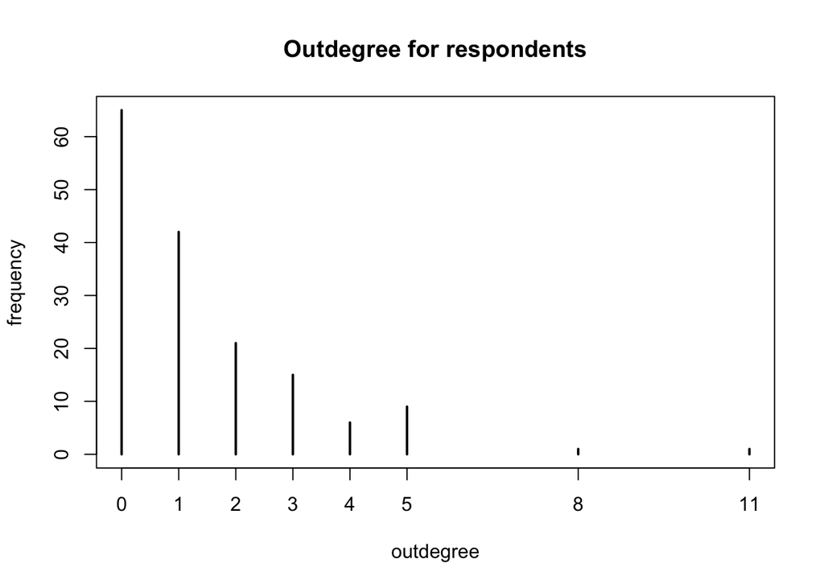

```r
plot( table(degree( ADJ, cmode="outdegree")[is.resopndent] ) , ylab='frequency',xlab='outdegree',main='Outdegree for respondents')
```

Provided that the non-repondents do not differ in how many (and whom) they would’ve nominated, the outdegree for respondents only indicate that this is indeed a very spare network with and average outdegree of

```r
mean(degree( ADJ, cmode="outdegree")[is.resopndent] )
```

```
## [1] 1.35625
```

We would consequently expect the density of the whole network to be something along the lines of

```r
xbar <- mean(degree( ADJ, cmode="outdegree")[is.resopndent] )
total.ties <- xbar*n
total.ties/(n*(n-1))
```

```
## [1] 0.003675474
```

#### Plot raw data

When we plot the network, the plot function treats missing ties as zeros. This is important to keep in mind. The following code writes the plot to a pdf in your current working directory

```r
pdf( 'rawnetwork.pdf' )
vertcol <- matrix( 'red',n,1 )
vertcol[is.resopndent] <- 'green'
plot( as.network(ADJ),
     vertex.col=vertcol,
     vertex.border=vertcol,
     arrowhead.cex = .25,
     vertex.cex = degree( ADJ, cmode="outdegree")*0.1+.1,
     usecurve=TRUE,
     edge.curv= 0.0025,
     edge.col='grey' )
dev.off( )
```

The plot should look someting like this

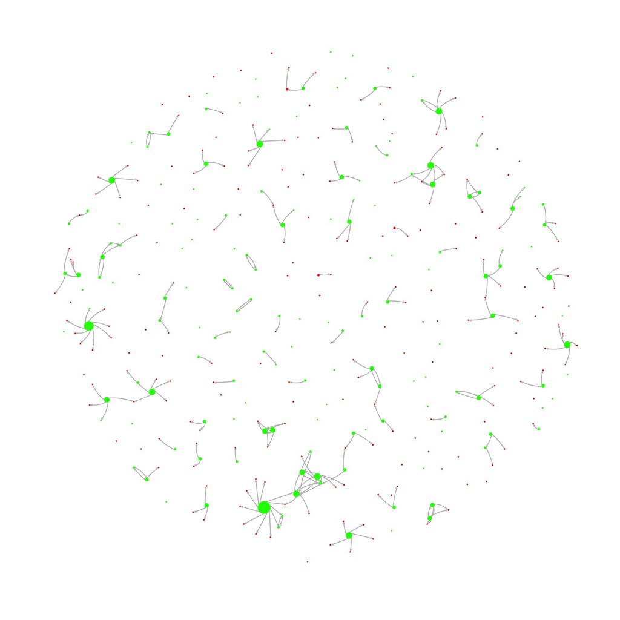

Network of observed ties only. Respondents (green) and non-respondents (red)

In the network we see clear examples of egonets where a respondent has nominated several non-respondents. In some rare cases, respondents are connected directly or indirectly to others. Confusingly there seems to be a few non-respondents that have actually nominated others.

> In the analysis we can chose to FORCE missing ties for non-respondents or set all out-going ties-variables of non-respondents to observed if the have made at least one nomination

## Imputation of node-level varaibles using MICE

To perform Multiple Imputation using Chained Equations, we rely on the package `MICE` (Van Buuren 2018). Make sure this is installed along with dependencies

```r
library(mice)
```

There are many resources and examples of usage for MICE. Myself I have relied a lot on https://datascienceplus.com/handling-missing-data-with-mice-package-a-simple-approach/ and https://datascienceplus.com/imputing-missing-data-with-r-mice-package/.

### Determine what variables to use

In this first example I use a maximal set of variables in the imputation.

```r
usevars <- c(6,7,8,9,10,11,12,13,14,15,18,19,22,23)# choose what variables to impute
names(MT_attr)[usevars] # important to check that we picked the right ones
```

```
##  [1] "agebs0"        "sexM0"         "TERTIARY_ED"   "A7_retired"
##  [5] "A7_employedFT" "fear"          "personloss"    "proploss"
##  [9] "PTSDsymp"      "dep_symp"      "PTSDsymp_T2"   "dep_symp_T2x"
## [13] "ANXT1"         "AVOIDT1"
```

To simplify things, extract and use only the varaibles to be used in imputation

```r
raw.data <- MT_attr[,usevars]
```

Note that the choice of variables to include is determined by what we want to use the imputed networks for. The maximal set used here includes all of a through d.

| Block | Variables | usage |
| --- | --- | --- |
| a. | PTSD | do not use when PTSD is DPV in network regression (e.g. ALAAM) |
| b. | Depression | do not use when depression is DPV in network regression (e.g. ALAAM) |
| c. | Variables at time 1 | note that you can use any variable that helps imputation even if they are not used in the ERGM or ALAAM |
| d. | Variables at time 2 | do not use when analysis is used for SAOM |

### Inspect missingness

There are a number of ways to inspect the patters of missingness. One is given by mice’s

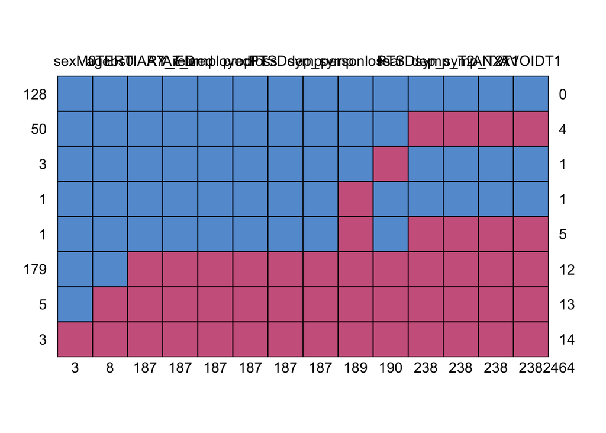

```
##     sexM0 agebs0 TERTIARY_ED A7_retired A7_employedFT proploss PTSDsymp
## 128     1      1           1          1             1        1        1
## 50      1      1           1          1             1        1        1
## 3       1      1           1          1             1        1        1
## 1       1      1           1          1             1        1        1
## 1       1      1           1          1             1        1        1
## 179     1      1           0          0             0        0        0
## 5       1      0           0          0             0        0        0
## 3       0      0           0          0             0        0        0
##         3      8         187        187           187      187      187
##     dep_symp personloss fear PTSDsymp_T2 dep_symp_T2x ANXT1 AVOIDT1
## 128        1          1    1           1            1     1       1    0
## 50         1          1    1           0            0     0       0    4
## 3          1          1    0           1            1     1       1    1
## 1          1          0    1           1            1     1       1    1
## 1          1          0    1           0            0     0       0    5
## 179        0          0    0           0            0     0       0   12
## 5          0          0    0           0            0     0       0   13
## 3          0          0    0           0            0     0       0   14
##          187        189  190         238          238   238     238 2464
```

```r
md.pattern(raw.data)
```

Anohter, graphical way is to use the package `VIM`

```r
library(VIM)
```

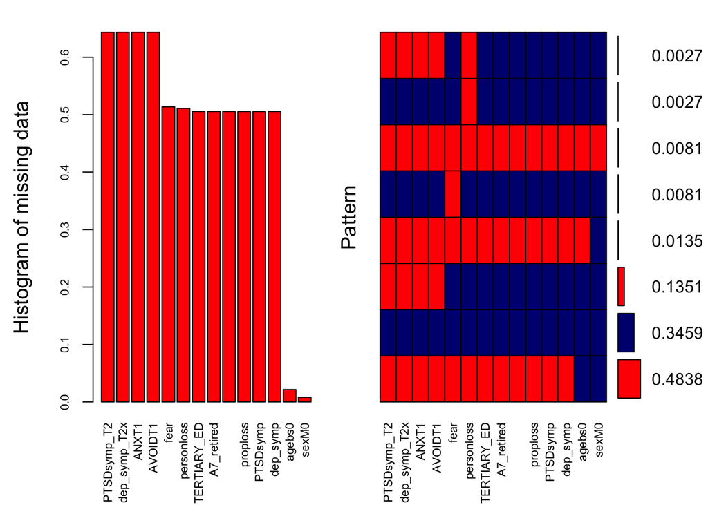

```
##
##  Variables sorted by number of missings:
##       Variable       Count
##    PTSDsymp_T2 0.643243243
##   dep_symp_T2x 0.643243243
##          ANXT1 0.643243243
##        AVOIDT1 0.643243243
##           fear 0.513513514
##     personloss 0.510810811
##    TERTIARY_ED 0.505405405
##     A7_retired 0.505405405
##  A7_employedFT 0.505405405
##       proploss 0.505405405
##       PTSDsymp 0.505405405
##       dep_symp 0.505405405
##         agebs0 0.021621622
##          sexM0 0.008108108
```

```r
aggr_plot <- aggr(raw.data, col=c('navyblue','red'),
                  numbers=TRUE,
                  sortVars=TRUE,
                  labels=names(data),
                  cex.axis=.7, gap=3, ylab=c("Histogram of missing data","Pattern"))
```

> The most common pattern is to have all varaibles apart from age and sex missing. The second most common pattern is to have all varaibles observed.

### Set up type of imputation

MICE has a range of differnt routines for imputing data, depending of the types of variables used. It does for example make sense to impute binary variable using logistic regression. The default procedure is predictive mean matching, ‘pmm’. For a trial run, let us set up the following imputation routine:

```r
init = mice(raw.data, maxit=0)
method.use = init$method
predM = init$predictorMatrix
#method.use <- rep('pmm',length(usevars))
method.use[1]<- 'norm.predict' # we can use OLS regression to impute continuous
method.use[c('sexM0')]<- 'logreg' # we can use logistic regression to impute binary
method.use[c('TERTIARY_ED')]<- 'logreg' # we can use logistic regression to impute binary
method.use[c('A7_employedFT')]<- 'logreg'
method.use[c('personloss')]<- 'logreg'
method.use[c('proploss')]<-  "polyreg"
method.use[c('PTSDsymp')]<-  "polyreg"
method.use[c('PTSDsymp_T2')]<-  "polyreg"
method.use[c('dep_symp')]<-  "polyreg"
method.use[c('dep_symp_T2x')]<-  "polyreg"
```

#### Run a short number of imputations

If we want to use the specified imputations above, the binary and ctegorical variables need to be recoded as factors. Then imputing, say 20 times, is done through

```r
imp1 <- mice(raw.data, m = 20, method= method.use )
```

To avoid this use teh default ‘pmm’ for now.

```r
imp1 <- mice(raw.data, m = 10 )
```

A brief summary of the imputations done are provided by

```r
summary( imp1 )
```

```
## Class: mids
## Number of multiple imputations:  10
## Imputation methods:
##        agebs0         sexM0   TERTIARY_ED    A7_retired A7_employedFT
##         "pmm"         "pmm"         "pmm"         "pmm"         "pmm"
##          fear    personloss      proploss      PTSDsymp      dep_symp
##         "pmm"         "pmm"         "pmm"         "pmm"         "pmm"
##   PTSDsymp_T2  dep_symp_T2x         ANXT1       AVOIDT1
##         "pmm"         "pmm"         "pmm"         "pmm"
## PredictorMatrix:
##               agebs0 sexM0 TERTIARY_ED A7_retired A7_employedFT fear personloss
## agebs0             0     1           1          1             1    1          1
## sexM0              1     0           1          1             1    1          1
## TERTIARY_ED        1     1           0          1             1    1          1
## A7_retired         1     1           1          0             1    1          1
## A7_employedFT      1     1           1          1             0    1          1
## fear               1     1           1          1             1    0          1
##               proploss PTSDsymp dep_symp PTSDsymp_T2 dep_symp_T2x ANXT1 AVOIDT1
## agebs0               1        1        1           1            1     1       1
## sexM0                1        1        1           1            1     1       1
## TERTIARY_ED          1        1        1           1            1     1       1
## A7_retired           1        1        1           1            1     1       1
## A7_employedFT        1        1        1           1            1     1       1
## fear                 1        1        1           1            1     1       1
```

There are several ways of diagnosing the imputations. A plot for the different depression scores across imputations is given by

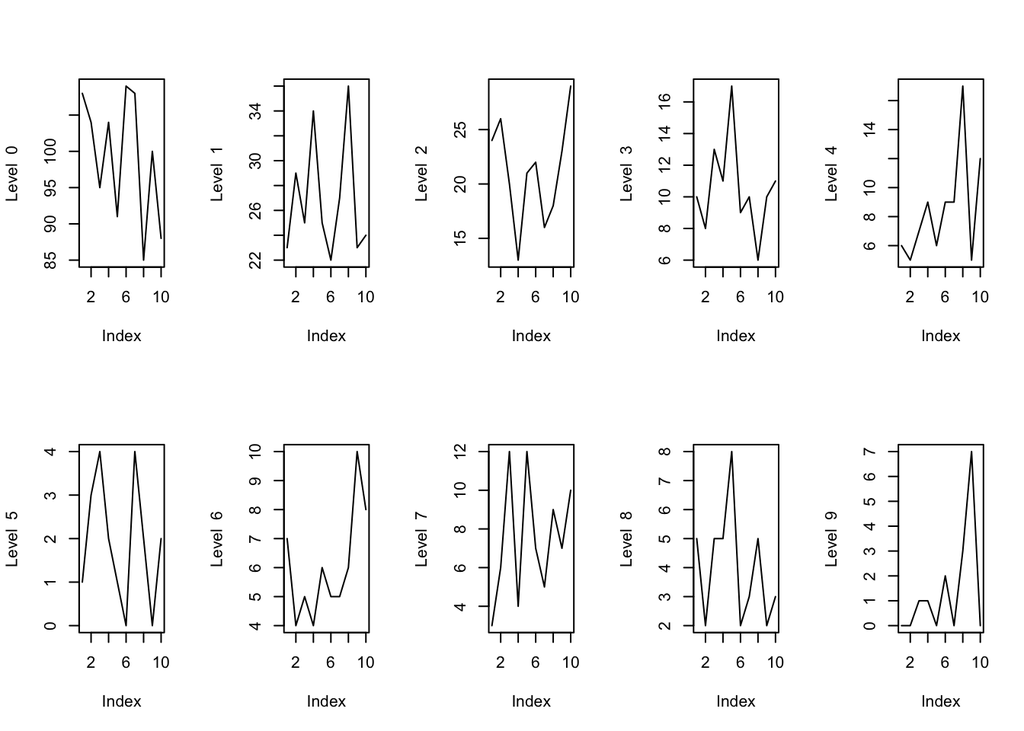

```r
par ( mfrow = c(2,5))
for (k in c(1:10))
{
plot(colSums(imp1$imp$dep_symp == (k-1)), type='l',ylab=paste('Level ',(k-1) ) )
}
```

If you are doing more imputations, it is worthwhile checking if there are any trends over interations.

## Paste the data back together again

There is a built in routine for replacing the missing values in the orginal dataset with values from the imputations

```r
imputed.data <- complete( imp1 , 5 )# taling the 5th imputed dataset
```

The imputations should have added values but roughly in proportion to the observed values

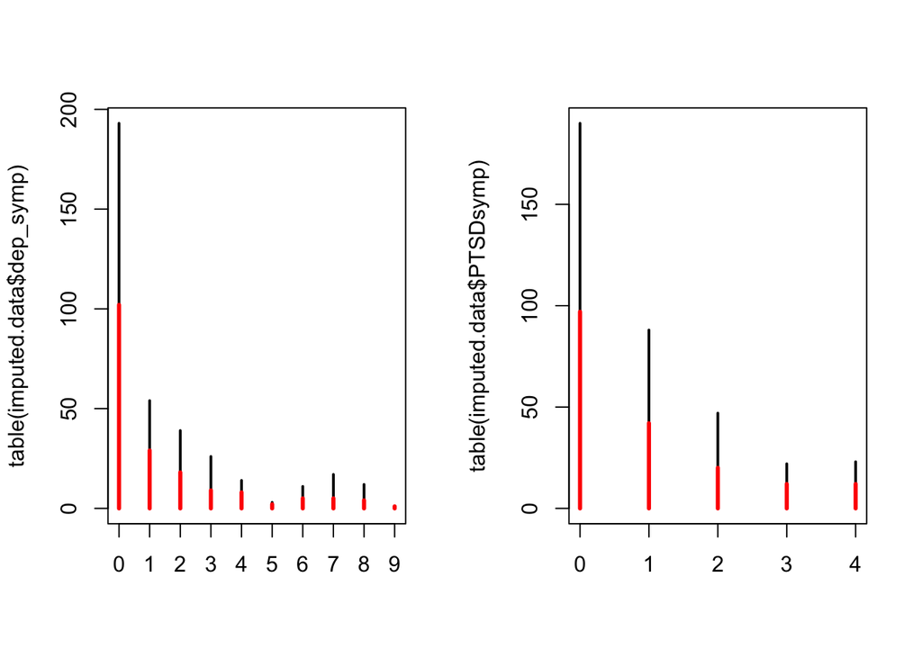

```r
par(mfrow=c(1,2))
plot( table(imputed.data$dep_symp) ) # spot-check of the imputed frequencies of depression
lines(table(MT_attr$dep_symp),lwd=3,col='red') # the observed frequencies

plot( table(imputed.data$PTSDsymp) )# spot-check of the imputed frequencies of PTSD
lines(table(MT_attr$PTSDsymp),lwd=3,col='red') # the observed frequencies
```

# Impute network ties using imputed nodal variables

We use the`ergm` package to format data.

```r
library(ergm)
```

### Format dataset

Define a network object with covariates

```r
net_test <- as.network(ADJ)
net_test %v% 'sextest' <- imputed.data$sexM0
net_test %v% 'agetest' <- (imputed.data$agebs0 -50)/100
net_test %v% 'edutest' <- imputed.data$TERTIARY_ED
net_test %v% 'depressiontest' <- (imputed.data$dep_symp - 4)/10
net_test %v% 'anxious' <- (imputed.data$ANXT1-2.75)/5.5
net_test %v% 'avoidant' <- (imputed.data$AVOIDT1 - 3)/6
```

Scaling the variables makes the estimation mor stable.

> Note that we have only picked one imputed attribute dateset here. If you standarddise using mean and standard deviation, the same value will mean different things across imputed datasets

### Spedicfy a model

Specify a model

```r
mod.1 <- net_test ~ edges+ # density
  mutual+ # reciprocation
  nodeicov('sextest')+ # indegree effect for sex
  nodeocov('sextest')+ # outdegree effect for sex
  nodematch('sextest')+ # homophily on sex
  nodeicov('agetest')+ # indegree effect for age
  nodeocov('agetest') +  # outdegree effect for age
  absdiff('agetest') +  # heterophily for age
  nodeicov('edutest')+ # indegree effect for education
  nodeocov('edutest')+ # outdegree effect for education
  nodematch('edutest')+ # homophily on education
  nodeicov('depressiontest')+ # indegree effect for depression
  nodeocov('depressiontest') + # outdegree effect for depression
  absdiff('depressiontest')+ #  heterophily on depression
  nodeicov('anxious')+ # indegree effect for anxious attachment
  nodeocov('anxious') + # outdegree effect for anxious attachment
  absdiff('anxious')+ # heterophily on anxious attachment
  nodeicov('avoidant')+ # indegree effect for avoidant attachment
  nodeocov('avoidant') + # outdegree effect for avoidant attachment
  absdiff('avoidant')+ # heterophily on avoidant attachment
  edgecov( HH ) + # homophily on being in same household
  gwidegree(0.25, fixed=TRUE)+ # alternating in-k-stars
  gwodegree(0.25, fixed=TRUE)+ # alternating out-k-stars
  gwesp(log(2), fixed=TRUE) # alternating k-triangle
```

### Load missing data routines for ERGM

The Bayesian data-augmentation scheme for ERGM builds on the elaboration by Koskinen et al. (2013) of the approach suggested in Koskinen, Robins, and Pattison (2010). Note that Koskinen et al. (2013) propose a missing data routine that simultaneously handles missing ties and missing attributes, with having to rely on MICE. That is a more prinicpled approach but it becomes very burdensome if there are many covariates of different nature.

The routines are implemented in the function `miss_ERGM_Bayes` which you find in the R-script ‘miss_ERGM_Bayes.r’. To use this function and the following functions, you need to read them in. Provided you have ‘miss_ERGM_Bayes.r’ in your current working directory, use the function `source()` to load the functions

```r
source('miss_ERGM_Bayes.r') # read in routines
```

### Run estimation

Run a short estimation with the specified model

```r
ans.1 <- miss_ERGM_Bayes(formula= mod.1, # the formula you specified earlier
                         tot.iterations = 1000 , # the total number of parameter draws; here deliberately too few
                         tuning.const = 0.01, # this sets the size of the jumps in the proposed moves
                         thinning = 1, # how many iterations to discard inbetween sample points
                         burnin = 1 , # how many iterations to discard before taking samples; here 1 so that we can monitor trend
                         save.nets = TRUE , # we want to output imputed networks
                         num.nets = 10, # the number of imputed networks to save
                         printFreq = 100, # how often do we print to screen
                         MultFac.aux =100 , # modifies the number of iterations for each sampled network as in MPNet
                         MultFac.miss =100, # modifies the number of iterations for each sampled imputed network as in MPNet
                         diagonal.proposal=TRUE, # if true parameter proposals are uncorrelated
                         save.name='trial.net',
                         warm.burnin=10000,
                         warm.thin = 10000)
```

```
## burnin auxiliary var draws:  50820  with multiplication factor:  100
## burnin missing var draws:  28765  with multiplication factor:  100
## simulating  1001  networks with thinning  10000 , total iterations:  10010000
## warming phase done
## at iteration  100  out of  1000  parameters:
## edges mutual nodeicov.sextest nodeocov.sextest nodematch.sextest nodeicov.agetest nodeocov.agetest absdiff.agetest nodeicov.edutest nodeocov.edutest nodematch.edutest nodeicov.depressiontest nodeocov.depressiontest absdiff.depressiontest nodeicov.anxious nodeocov.anxious absdiff.anxious nodeicov.…
## -5.771 2.432 0.047 -0.041 0.028 -0.22 0.127 0.164 0.017 0.116 -0.047 -0.039 -0.103 0.182 -0.203 0.047 -0.065 0.269 0.145 -0.14 0.918 0.16 0.048 0.921
## num auxiliary ties:  498  and imputed ties:  487
## at iteration  200  out of  1000  parameters:
## edges mutual nodeicov.sextest nodeocov.sextest nodematch.sextest nodeicov.agetest nodeocov.agetest absdiff.agetest nodeicov.edutest nodeocov.edutest nodematch.edutest nodeicov.depressiontest nodeocov.depressiontest absdiff.depressiontest nodeicov.anxious nodeocov.anxious absdiff.anxious nodeicov.…
## -5.605 2.827 0.124 -0.133 0.055 -0.502 0.377 0.11 0.097 -0.096 -0.051 -0.162 0.007 0.045 0.164 0.039 0.084 0.348 0.235 -0.398 2.478 0.031 -0.156 1.535
## num auxiliary ties:  589  and imputed ties:  530
## at iteration  300  out of  1000  parameters:
## edges mutual nodeicov.sextest nodeocov.sextest nodematch.sextest nodeicov.agetest nodeocov.agetest absdiff.agetest nodeicov.edutest nodeocov.edutest nodematch.edutest nodeicov.depressiontest nodeocov.depressiontest absdiff.depressiontest nodeicov.anxious nodeocov.anxious absdiff.anxious nodeicov.…
## -5.714 2.706 -0.003 0.008 -0.016 -0.757 0.704 -0.21 0.061 0.049 -0.019 -0.251 -0.023 0.125 0.388 0.096 -0.07 0.424 0.282 -0.377 3.136 0.334 -0.408 0.407
## num auxiliary ties:  451  and imputed ties:  492
## at iteration  400  out of  1000  parameters:
## edges mutual nodeicov.sextest nodeocov.sextest nodematch.sextest nodeicov.agetest nodeocov.agetest absdiff.agetest nodeicov.edutest nodeocov.edutest nodematch.edutest nodeicov.depressiontest nodeocov.depressiontest absdiff.depressiontest nodeicov.anxious nodeocov.anxious absdiff.anxious nodeicov.…
## -6.018 3.683 0.092 0.027 0.05 -0.75 0.765 -0.574 0.201 0.186 0.077 0.009 -0.265 0.225 0.099 -0.008 -0.059 0.598 0.103 -0.452 3.38 0.437 -0.502 -0.003
## num auxiliary ties:  479  and imputed ties:  424
## at iteration  500  out of  1000  parameters:
## edges mutual nodeicov.sextest nodeocov.sextest nodematch.sextest nodeicov.agetest nodeocov.agetest absdiff.agetest nodeicov.edutest nodeocov.edutest nodematch.edutest nodeicov.depressiontest nodeocov.depressiontest absdiff.depressiontest nodeicov.anxious nodeocov.anxious absdiff.anxious nodeicov.…
## -6.17 2.846 0.072 0.072 0.001 -0.963 0.941 -0.37 0.178 0.253 0.141 0.11 -0.302 0.126 0.021 0.059 -0.18 0.508 0.044 -0.741 3.96 0.606 -0.617 0.551
## num auxiliary ties:  382  and imputed ties:  468
## at iteration  600  out of  1000  parameters:
## edges mutual nodeicov.sextest nodeocov.sextest nodematch.sextest nodeicov.agetest nodeocov.agetest absdiff.agetest nodeicov.edutest nodeocov.edutest nodematch.edutest nodeicov.depressiontest nodeocov.depressiontest absdiff.depressiontest nodeicov.anxious nodeocov.anxious absdiff.anxious nodeicov.…
## -6.066 1.55 0.113 0.216 0.053 -0.941 0.99 -0.875 0.057 0.205 0.084 -0.099 -0.351 0.157 0.073 0.156 -0.033 0.605 0.054 -0.778 4.358 0.553 -0.992 0.558
## num auxiliary ties:  391  and imputed ties:  451
## at iteration  700  out of  1000  parameters:
## edges mutual nodeicov.sextest nodeocov.sextest nodematch.sextest nodeicov.agetest nodeocov.agetest absdiff.agetest nodeicov.edutest nodeocov.edutest nodematch.edutest nodeicov.depressiontest nodeocov.depressiontest absdiff.depressiontest nodeicov.anxious nodeocov.anxious absdiff.anxious nodeicov.…
## -5.98 1.514 0.161 0.203 0.036 -0.727 1.109 -1.145 -0.062 0.218 0.073 -0.157 -0.387 0.033 0.153 0.02 -0.199 0.525 -0.334 -1.017 4.902 0.609 -1.087 0.797
## num auxiliary ties:  416  and imputed ties:  367
## at iteration  800  out of  1000  parameters:
## edges mutual nodeicov.sextest nodeocov.sextest nodematch.sextest nodeicov.agetest nodeocov.agetest absdiff.agetest nodeicov.edutest nodeocov.edutest nodematch.edutest nodeicov.depressiontest nodeocov.depressiontest absdiff.depressiontest nodeicov.anxious nodeocov.anxious absdiff.anxious nodeicov.…
## -5.928 1.041 0.181 0.264 0.065 -0.777 0.867 -1.688 -0.16 0.157 0.048 -0.119 -0.32 -0.441 0.204 0.182 0.17 0.656 -0.487 -0.587 5.279 0.51 -1.111 0.788
## num auxiliary ties:  397  and imputed ties:  379
## at iteration  900  out of  1000  parameters:
## edges mutual nodeicov.sextest nodeocov.sextest nodematch.sextest nodeicov.agetest nodeocov.agetest absdiff.agetest nodeicov.edutest nodeocov.edutest nodematch.edutest nodeicov.depressiontest nodeocov.depressiontest absdiff.depressiontest nodeicov.anxious nodeocov.anxious absdiff.anxious nodeicov.…
## -5.887 1.061 0.191 0.206 0.179 -1.067 1.14 -1.714 -0.225 0.041 0.061 -0.16 -0.422 -0.539 0.193 0.428 0.077 0.775 -0.471 -0.516 5.365 0.697 -1.263 0.225
## num auxiliary ties:  350  and imputed ties:  377
## at iteration  1000  out of  1000  parameters:
## edges mutual nodeicov.sextest nodeocov.sextest nodematch.sextest nodeicov.agetest nodeocov.agetest absdiff.agetest nodeicov.edutest nodeocov.edutest nodematch.edutest nodeicov.depressiontest nodeocov.depressiontest absdiff.depressiontest nodeicov.anxious nodeocov.anxious absdiff.anxious nodeicov.…
## -5.871 0.912 0.08 0.257 0.211 -0.699 1.048 -1.696 -0.201 -0.03 0.212 -0.003 -0.355 -0.774 0.189 0.389 0.109 0.858 -0.49 -0.516 5.269 0.832 -1.058 0.278
## num auxiliary ties:  429  and imputed ties:  395
```

The objects returned are

```r
names(ans.1)
```

```
## [1] "Post.theta" "aux.nets"   "mix.nets"
```

Parameters are called ‘Thetas’.

#### Inspect quality of MCMC chains

Plot the trace plots for some of the parameters

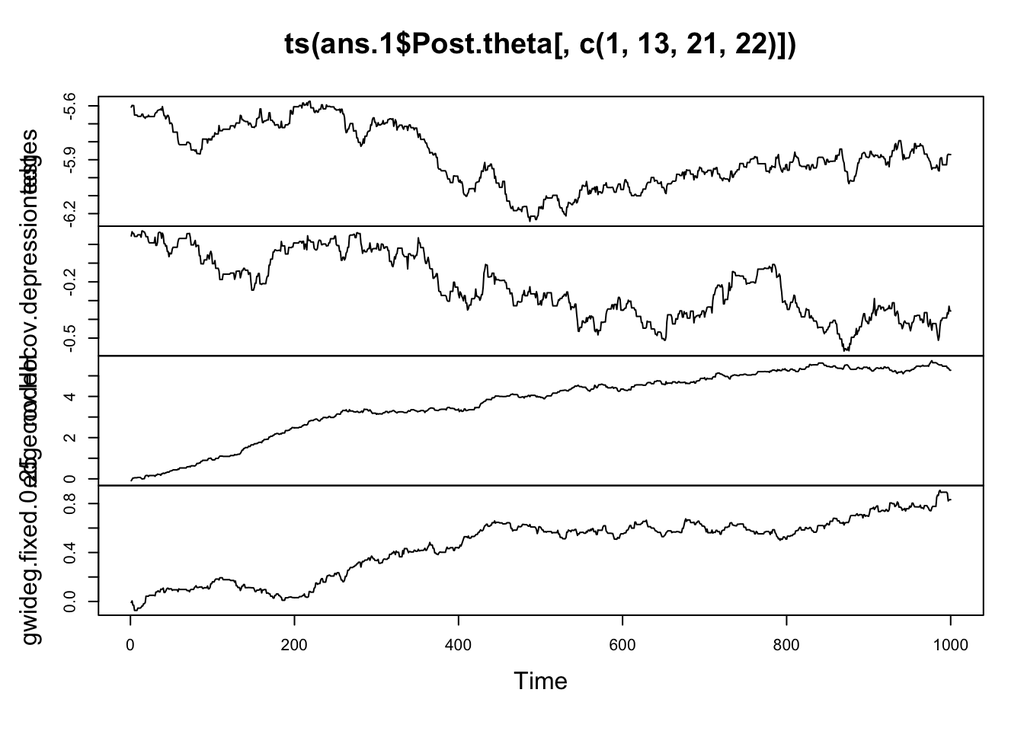

```r
plot(ts(ans.1$Post.theta[,c(1,13,21,22)]))# edges, nodeocovdepression, HH, gwideg
```

> Parameters clearly are still drifting and wandering away from their initial starting points.

We need to restart in better initial values

> Chains have high serial autocorrelation

Plotting the sample autocorrelation for ‘gwideg’ shows that values 30 iterations apart have a 0.9 correlation.

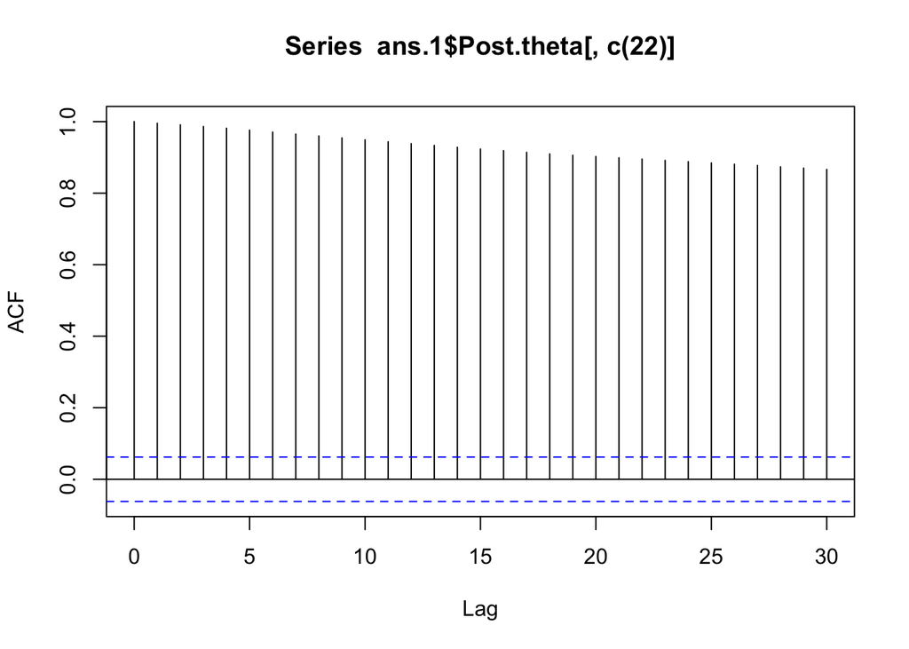

```r
acf(ans.1$Post.theta[,c(22)])
```

#### Improving initial values

We take the last value from the estimation as our next starting point:

```r
start.theta <- ans.1$Post.theta[1000,]
```

#### Improving mixing

We can improve on how well the chains move by using a better variance-covariance matrix for the proposal distributions. Method one relies on properties of exponential family distributions and the fact that the covariance of statistics is the inverse of the covariance of parameters.

```r
test.stats <- simulate(mod.1,coef= start.theta , nsim=1000, output = 'stats' )# simulate the statistics of 100 networks
prop.var <- solve(cov(test.stats)) # this could be a good proposal variance
```

If the MCMC sample `ans.1$Post.theta` is of sufficient quality, then the covariance of the draws should be close to optimal as a proposal covariance matrix

```r
prop.var <- cov( ans.1$Post.theta[500:1000,] ) # this is a enstimate of the scales and covariance of parameters
```

### Refit model

Fit the model again, starting in better initial values and with a better proposal covariance matrix.

```r
ans.2 <- miss_ERGM_Bayes(formula= mod.1, # model is unchanged
                         tot.iterations = 4000 ,
                         tuning.const = 0.8, # if the size of the changes are too big/small tuning.const scaled the jumps
                         thinning = 1, # if you are confident that sample will be good but SACF high, you can space out sample points
                         burnin = 1 ,
                         save.nets = TRUE , # we want to save some imputed networks
                         num.nets = 50, # save some imputed networks for goodness of fit and diagnostics
                         printFreq = 400, # print updates 10 times to screen
                         MultFac.aux =200 ,
                         MultFac.miss =200,
                         diagonal.proposal=FALSE, # if covariances estimates in prop.var are good we want to use that
                         save.name='trial.net', # every time output is printed to screen, current state will be saved to a dump with this name
                         warm.burnin=10000,
                         warm.thin = 10000,
                         sigma.epsilon = prop.var , # the new and improved proposal covariance matrix
                         theta=start.theta ) # better initial values will help MCMC to get to the right place quicker
```

```
## burnin auxiliary var draws:  101640  with multiplication factor:  200
## burnin missing var draws:  57530  with multiplication factor:  200
## at iteration  400  out of  4000  parameters:
## edges mutual nodeicov.sextest nodeocov.sextest nodematch.sextest nodeicov.agetest nodeocov.agetest absdiff.agetest nodeicov.edutest nodeocov.edutest nodematch.edutest nodeicov.depressiontest nodeocov.depressiontest absdiff.depressiontest nodeicov.anxious nodeocov.anxious absdiff.anxious nodeicov.…
## -5.849 0.459 0.135 0.165 0.177 -1.159 1.04 -2.127 -0.24 -0.12 0.119 -0.003 0.172 -0.588 0.172 0.875 0.271 1.372 -1.507 -0.103 5.561 1.086 -1.22 0.579
## num auxiliary ties:  402  and imputed ties:  397
## at iteration  800  out of  4000  parameters:
## edges mutual nodeicov.sextest nodeocov.sextest nodematch.sextest nodeicov.agetest nodeocov.agetest absdiff.agetest nodeicov.edutest nodeocov.edutest nodematch.edutest nodeicov.depressiontest nodeocov.depressiontest absdiff.depressiontest nodeicov.anxious nodeocov.anxious absdiff.anxious nodeicov.…
## -5.851 2.967 0.11 0.058 -0.086 -0.964 1.53 -1.371 0.036 -0.127 0.08 -0.179 0.328 -0.106 -0.234 0.708 -0.045 1.233 -1.125 -0.409 4.397 1.228 -1.554 0.433
## num auxiliary ties:  448  and imputed ties:  409
## at iteration  1200  out of  4000  parameters:
## edges mutual nodeicov.sextest nodeocov.sextest nodematch.sextest nodeicov.agetest nodeocov.agetest absdiff.agetest nodeicov.edutest nodeocov.edutest nodematch.edutest nodeicov.depressiontest nodeocov.depressiontest absdiff.depressiontest nodeicov.anxious nodeocov.anxious absdiff.anxious nodeicov.…
## -5.679 1.51 0.16 0.069 -0.014 -1.181 1.045 -2.157 0.012 0.001 0.026 0.019 0.542 -0.385 -0.224 1.073 0.167 1.27 -1.504 -0.152 5.002 1.102 -1.188 0.36
## num auxiliary ties:  418  and imputed ties:  429
## at iteration  1600  out of  4000  parameters:
## edges mutual nodeicov.sextest nodeocov.sextest nodematch.sextest nodeicov.agetest nodeocov.agetest absdiff.agetest nodeicov.edutest nodeocov.edutest nodematch.edutest nodeicov.depressiontest nodeocov.depressiontest absdiff.depressiontest nodeicov.anxious nodeocov.anxious absdiff.anxious nodeicov.…
## -5.595 0.105 0.172 -0.06 0.192 -1.34 1.59 -2.288 0.143 -0.196 -0.061 0.284 -0.065 -0.459 -0.067 1.396 -0.226 1.322 -1.077 -0.211 5.604 1.138 -1.534 0.798
## num auxiliary ties:  334  and imputed ties:  365
## at iteration  2000  out of  4000  parameters:
## edges mutual nodeicov.sextest nodeocov.sextest nodematch.sextest nodeicov.agetest nodeocov.agetest absdiff.agetest nodeicov.edutest nodeocov.edutest nodematch.edutest nodeicov.depressiontest nodeocov.depressiontest absdiff.depressiontest nodeicov.anxious nodeocov.anxious absdiff.anxious nodeicov.…
## -5.439 -0.719 0.249 0.02 0.074 -1.11 1.156 -2.237 0.131 -0.054 -0.098 0.756 0.2 -0.518 -0.276 1.191 -0.195 0.835 -1.113 -0.511 5.892 0.901 -1.244 0.656
## num auxiliary ties:  409  and imputed ties:  366
## at iteration  2400  out of  4000  parameters:
## edges mutual nodeicov.sextest nodeocov.sextest nodematch.sextest nodeicov.agetest nodeocov.agetest absdiff.agetest nodeicov.edutest nodeocov.edutest nodematch.edutest nodeicov.depressiontest nodeocov.depressiontest absdiff.depressiontest nodeicov.anxious nodeocov.anxious absdiff.anxious nodeicov.…
## -5.537 -0.945 0.222 0.082 0.03 -0.798 1.484 -2.111 0.055 0.051 -0.052 0.424 -0.139 -0.677 -0.562 0.859 -0.389 1.188 -0.209 -0.774 6.092 1.284 -1.312 0.835
## num auxiliary ties:  355  and imputed ties:  365
## at iteration  2800  out of  4000  parameters:
## edges mutual nodeicov.sextest nodeocov.sextest nodematch.sextest nodeicov.agetest nodeocov.agetest absdiff.agetest nodeicov.edutest nodeocov.edutest nodematch.edutest nodeicov.depressiontest nodeocov.depressiontest absdiff.depressiontest nodeicov.anxious nodeocov.anxious absdiff.anxious nodeicov.…
## -5.169 -0.787 0.275 0.14 0.084 -0.652 1.105 -2.229 -0.153 -0.015 -0.044 0.617 -0.062 -0.811 -0.788 0.979 -0.95 1.15 -0.086 -0.917 5.918 1.484 -1.268 0.604
## num auxiliary ties:  450  and imputed ties:  413
## at iteration  3200  out of  4000  parameters:
## edges mutual nodeicov.sextest nodeocov.sextest nodematch.sextest nodeicov.agetest nodeocov.agetest absdiff.agetest nodeicov.edutest nodeocov.edutest nodematch.edutest nodeicov.depressiontest nodeocov.depressiontest absdiff.depressiontest nodeicov.anxious nodeocov.anxious absdiff.anxious nodeicov.…
## -5.318 -1.096 0.35 0.3 0.062 -0.742 1.051 -2.412 -0.053 0.046 0.021 1.176 0.384 -1.023 -0.538 0.898 -0.312 1.255 -0.772 -0.677 5.986 0.969 -1.242 0.922
## num auxiliary ties:  367  and imputed ties:  377
## at iteration  3600  out of  4000  parameters:
## edges mutual nodeicov.sextest nodeocov.sextest nodematch.sextest nodeicov.agetest nodeocov.agetest absdiff.agetest nodeicov.edutest nodeocov.edutest nodematch.edutest nodeicov.depressiontest nodeocov.depressiontest absdiff.depressiontest nodeicov.anxious nodeocov.anxious absdiff.anxious nodeicov.…
## -5.235 -0.676 0.416 0.216 0.008 -1.094 1.66 -2.621 -0.199 -0.007 -0.077 0.9 0.378 -1.164 -0.213 1.459 -0.289 0.74 -0.739 -0.454 6.37 0.872 -1.573 0.697
## num auxiliary ties:  296  and imputed ties:  336
## at iteration  4000  out of  4000  parameters:
## edges mutual nodeicov.sextest nodeocov.sextest nodematch.sextest nodeicov.agetest nodeocov.agetest absdiff.agetest nodeicov.edutest nodeocov.edutest nodematch.edutest nodeicov.depressiontest nodeocov.depressiontest absdiff.depressiontest nodeicov.anxious nodeocov.anxious absdiff.anxious nodeicov.…
## -5.648 0.74 0.57 0.342 0.019 -1.242 1.347 -2.319 -0.074 0.218 -0.037 0.31 0.063 -0.052 -0.159 1.363 -0.222 0.904 -0.775 -0.952 5.856 0.616 -1.58 0.195
## num auxiliary ties:  348  and imputed ties:  360
```

> If you were confident that the starting values were good, sigma.epsilon good, and tuning.const close to optimal, set tot.iterations high and set thinning larger. This way you will get fewer draws, as the draws will be more spaced out, but ESS will get closer to the total sample size.

### Diagnosing output

Look at the trace plots for some paramters

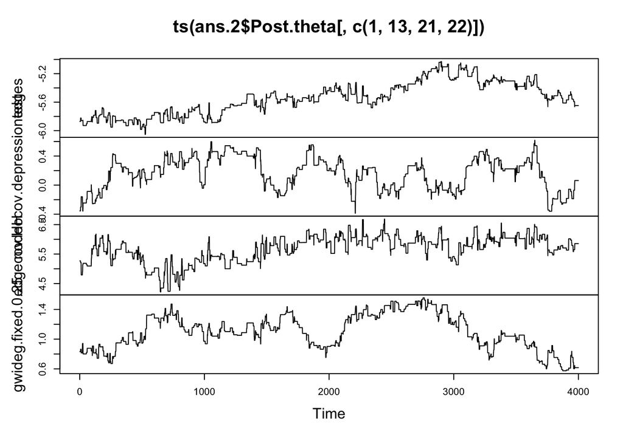

```r
plot(ts(ans.2$Post.theta[,c(1,13,21,22)]))# edges, nodeocovdepression, HH, gwideg
```

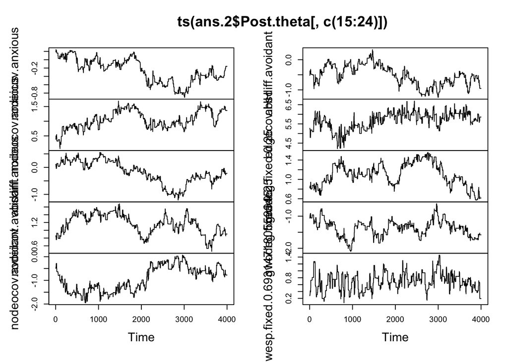

```r
plot(ts(ans.2$Post.theta[,c(15:24)]))# the last three are alternating stars and triangles
```

If parameters are no longer drifting, then initial value is good. If the chains do not move often enough, then (a) the constant `tuning.const` can be set lower, or (b) a better proposal variance used.

> The number of iterations are set deliberately too low and if these were increased, that would give us more interations that we could use

#### Further diagnostics

Load the package `coda`

```r
library(coda)
```

### Printing results

If we feel confident that we have results that are trustworthy and the ESS is sufficiently high, then can print the results to a table. The posterior means and posterior standard deviations should not be sensititve to autocorrelation in the chains. The 95% Credibility intervalls on the other hand are sensitive to the number of independent draws they are base upon.

Even if you have high correlation in your posteriors, you can account for this by increasing the thinning, only taking observatinos at some distance apart. This distance is called *thinning*. Let’s say that the correlation at lag 30 is below 0.4 for all parameters, then we can set the thinning to 30. If we have $N$ iterations, then the total number of draws the summaries would be based upon would be $N/30$.

Use some thinning and discard the first 500 iterations as burnin. A results table can be printed

```r
creatTab(ans.2$Post.theta, thinning = 20, burnin=500)
```

```
##                           effect   mean    sd CI 0.025 CI 0.975
## 1                          edges -5.503 0.207   -5.890   -5.105
## 2                         mutual  0.201 0.978   -1.147    2.229
## 3               nodeicov.sextest  0.258 0.123    0.098    0.552
## 4               nodeocov.sextest  0.133 0.133   -0.075    0.425
## 5              nodematch.sextest  0.055 0.082   -0.107    0.227
## 6               nodeicov.agetest -1.006 0.360   -1.665   -0.233
## 7               nodeocov.agetest  1.314 0.317    0.646    1.894
## 8                absdiff.agetest -2.320 0.293   -2.900   -1.806
## 9               nodeicov.edutest -0.063 0.118   -0.319    0.160
## 10              nodeocov.edutest -0.042 0.119   -0.297    0.149
## 11             nodematch.edutest -0.014 0.090   -0.181    0.149
## 12       nodeicov.depressiontest  0.395 0.444   -0.418    1.176
## 13       nodeocov.depressiontest  0.181 0.217   -0.233    0.515
## 14        absdiff.depressiontest -0.641 0.305   -1.398   -0.106
## 15              nodeicov.anxious -0.316 0.259   -0.791    0.103
## 16              nodeocov.anxious  1.103 0.267    0.707    1.536
## 17               absdiff.anxious -0.242 0.413   -1.012    0.406
## 18             nodeicov.avoidant  1.164 0.253    0.620    1.523
## 19             nodeocov.avoidant -0.909 0.531   -1.840   -0.055
## 20              absdiff.avoidant -0.538 0.336   -1.152    0.051
## 21                    edgecov.HH  5.692 0.440    4.792    6.344
## 22             gwideg.fixed.0.25  1.130 0.233    0.616    1.509
## 23             gwodeg.fixed.0.25 -1.407 0.251   -1.920   -0.939
## 24 gwesp.fixed.0.693147180559945  0.707 0.238    0.256    1.156
```

### Inspecting imputed networks

It is good practice to do spotchecks of the imputed networks to get a sense of whether these are realistic or not. We can plot any of the imputed networks. The 50th imputed network is stored in `ans.2$mix.nets[[50]]`.

```r
pdf( 'imputednework.pdf' )
vertcol <- matrix( 'red',n,1 )
vertcol[is.resopndent] <- 'green'
plot( ans.2$mix.nets[[50]],
      vertex.col=vertcol,
      vertex.border=vertcol,
      arrowhead.cex = .25,
      vertex.cex = degree( ADJ, cmode="outdegree")*0.1+.1,
      usecurve=TRUE,
      edge.curv= 0.0025,
      edge.col='grey' )
dev.off( )
```

The plot should look someting like this

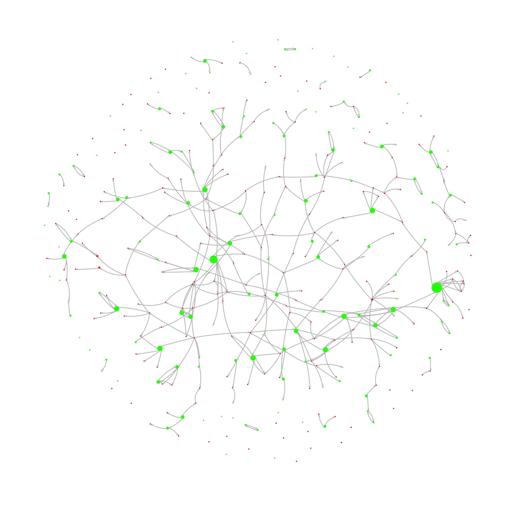

Imputed network. Respondents (green) and non-respondents (red)

### Density, dyad-, and triad censuses

Calculating density

```r
gden(ans.2$mix.nets ) # you can also plot these
```

```
##  [1] 0.003024976 0.002966381 0.002431700 0.002841866 0.002907786 0.003017652
##  [7] 0.002658756 0.002658756 0.002417051 0.002995679 0.002453673 0.002548890
## [13] 0.002578188 0.002578188 0.003142167 0.002900461 0.002797920 0.002717351
## [19] 0.002622134 0.002673405 0.002497620 0.002878488 0.002710027 0.002680730
## [25] 0.002680730 0.002739325 0.002695378 0.002607486 0.002797920 0.002673405
## [31] 0.002790595 0.002819893 0.002644108 0.002622134 0.003024976 0.003186113
## [37] 0.003178789 0.003164140 0.003156815 0.002761298 0.002600161 0.002636783
## [43] 0.002644108 0.002710027 0.002460998 0.002570864 0.002966381 0.002746649
## [49] 0.002651432 0.002636783
```

Calculating dyad census

```r
dyad.census(ans.2$mix.nets ) # you could plot the number of mutual over time in the first column
```

```
##       Mut Asym  Null
##  [1,]  37  339 67889
##  [2,]  39  327 67899
##  [3,]  29  274 67962
##  [4,]  28  332 67905
##  [5,]  36  325 67904
##  [6,]  28  356 67881
##  [7,]  33  297 67935
##  [8,]  37  289 67939
##  [9,]  27  276 67962
## [10,]  37  335 67893
## [11,]  29  277 67959
## [12,]  35  278 67952
## [13,]  30  292 67943
## [14,]  30  292 67943
```

[output cut: 36 more lines]

Calculating triad census

```r
triad.census(ans.2$mix.nets ) #
```

```
##           003    012   102 021D 021U 021C 111D 111U 030T 030C 201 120D 120U
##  [1,] 8236295 123271 13478  282   99  276   27   81   12    0   4    3    5
##  [2,] 8239940 118944 14195  274   85  253   34   85    7    0   3    2    6
##  [3,] 8262921  99798 10571  241   45  156   21   49   17    0   3    3    4
##  [4,] 8242143 120743 10196  283   88  277   18   64   12    0   3    1    5
##  [5,] 8241759 118224 13116  275   85  253   37   62    7    1   3    2    6
##  [6,] 8233399 129400 10203  339  111  282   21   50   14    0   2    3    9
##  [7,] 8253045 108147 12036  240   56  202   13   66   16    0   2    1    7
##  [8,] 8254493 105258 13497  239   49  181   18   72   13    0   4    5    6
##  [9,] 8262917 100520  9843  275   39  150   24   49   10    0   2    1    5
## [10,] 8237728 121887 13470  307   81  215   32   88   14    1   3    1    6
## [11,] 8261834 100848 10575  261   50  175   19   57    8    0   2    1    4
## [12,] 8259295 101170 12765  259   55  180   21   62   13    1   4    1    4
## [13,] 8255969 106333 10937  283   59  154   21   58   11    0   2    1    5
## [14,] 8255975 106315 10948  286   53  166   20   44   16    0   4    2    3
```

[output cut: 87 more lines]

## Goodness-of-fit: comparing impputed and predicted

We can compare the imputed networks `ans.2$mix.nets` with the networks `aux.nets` predicted by the model manually using desnity, dyad, or triad census. Any number of functions of the imputed and predicted networks can be calculated, to investigate how the model fits a population network (Stys et al. 2020)

### GOF for degree distribution

The GOF distributions for degree are given by

```r
gofdegs <- gof.degree(ans.2)
```

A plot function superimposes the imputed and precicted

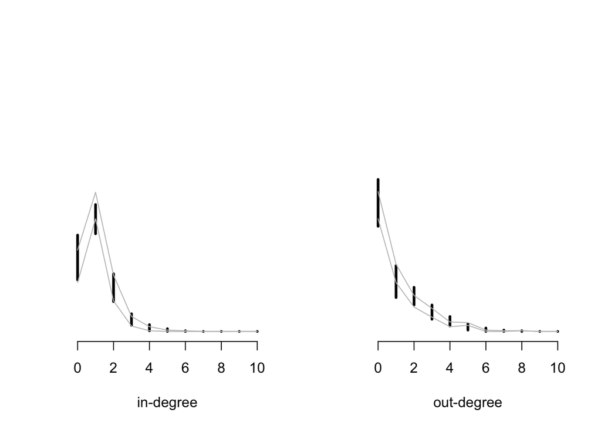

```r
plot.gof.degree(gofdegs,max.deg.plot.ind = 11)
```

#### Checking imputed degree distributions against the observed degree distributions for respondents

If data are missing at random, we would expect that the outdegree distribution for the imputed networks is similar to the outdegree distributions for the respondents.

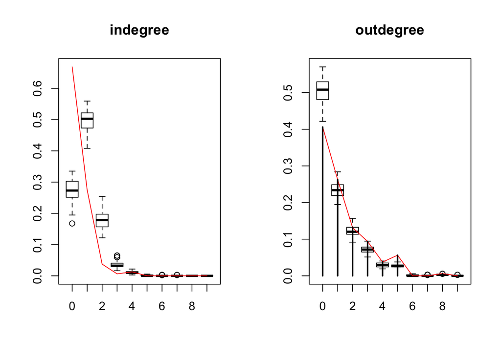

```r
tempdeg <- gof.obs.degree(obs.net=net_test,mat=ans.2,is.resopndent=is.resopndent ,directed=TRUE)
par(mfrow=c(1,2))
boxplot(tempdeg$mix.indeg[,1:10],ylim=range(tempdeg$mix.indeg[,1:10],tempdeg$aux.indeg[1:10] ),main='indegree' ,names=c(0:9))
lines(tempdeg$aux.indeg[1:10],col='red')
boxplot(tempdeg$mix.oudeg[,1:10],ylim=range(tempdeg$mix.oudeg[,1:10],tempdeg$aux.oudegg[1:10] ) ,main='outdegree',names=c(0:9))
lines(tempdeg$aux.oudeg[1:10],col='red')
lines(table(rowSums(ADJ)[is.resopndent]+1)/sum(is.resopndent))
```

### GOF for geodesic distances

The GOF distributions for distances are given by

```r
gofdist <- gof.dist(ans.2, directed=TRUE , max.path = 35)
```

A plot function superimposes the imputed and precicted

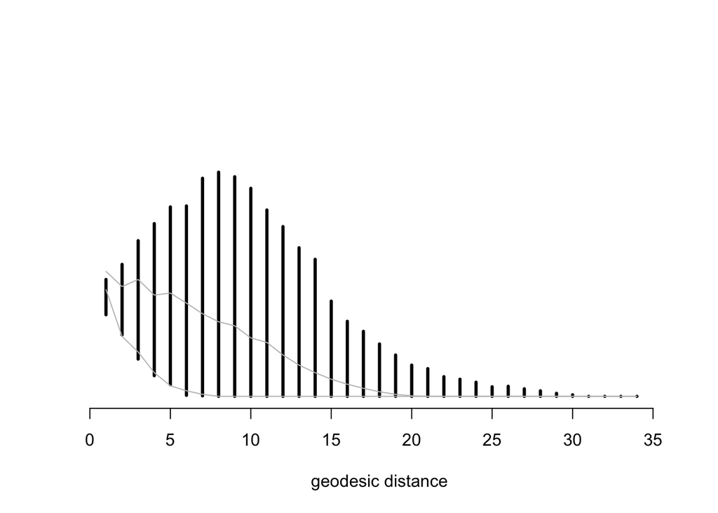

```r
plot.gof.dist(gofdist,max.dist.plot.ind = 35,do.inf.dist=FALSE)
```

### GOF for edge-wise shared partners

The GOF distributions for edge-wise shared partners are given by

```r
gofesp <- gof.esp(ans=ans.2,directed=TRUE)
```

A plot function superimposes the imputed and precicted

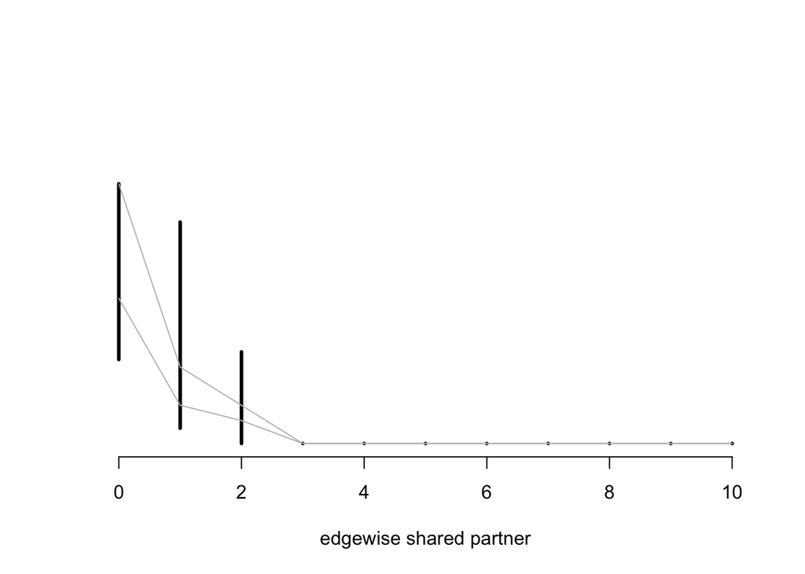

```r
plot.gof.esp(gofesp= gofesp)
```

### Manually inspect the triad census

Calculate the triad census for the predicted networks and the imputed networks

```r
TriadPred <- triad.census(ans.2$aux.nets)
TriadImputed <- triad.census(ans.2$mix.nets)
```

Compare, side by side, the triad counts of the predicted networks and the imputed networks.

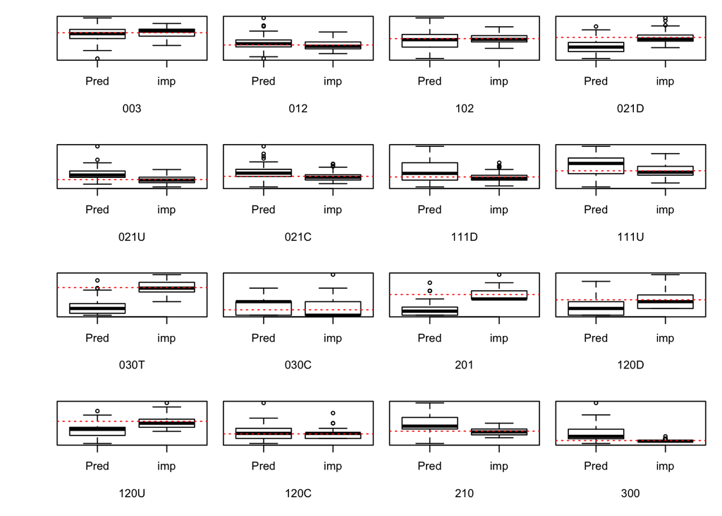

```r
par( mfrow = c(4,4), oma = c(0,4,0,0) + 0.1,
      mar = c(5,0,1,1) + 0.1)# oma sets outer margins and mar the margins
for (j in c(1:16)){
boxplot(TriadPred[,j],TriadImputed[,j],names = c('Pred','imp'), xlab=colnames(TriadPred)[j], yaxt='n' )
 abline(h=mean(TriadImputed[,j]),col='red',lty=3)
  }
```

## Combining imputed analyses

Results `ans.2` are based on one set of imputed covariates. Perform an analysis based on another set of imputed covariates by first respecifying the network data and model.

#### Pick new imputed values

Pick another set of imputed values

```r
imputed.data <- complete( imp1 , 10 )# taking the 10th imputed dataset
```

#### Recreate the network object

Define a network object with covariates

```r
net_test <- as.network(ADJ)
net_test %v% 'sextest' <- imputed.data$sexM0
net_test %v% 'agetest' <- (imputed.data$agebs0 -50)/100
net_test %v% 'edutest' <- imputed.data$TERTIARY_ED
net_test %v% 'depressiontest' <- (imputed.data$dep_symp - 4)/10
net_test %v% 'anxious' <- (imputed.data$ANXT1-2.75)/5.5
net_test %v% 'avoidant' <- (imputed.data$AVOIDT1 - 3)/6
```

Note that we use the same constants for scaling the covariates.

#### Respedicfy a model

Specify a model

```r
mod.1 <- net_test ~ edges+ # density
  mutual+ # reciprocation
  nodeicov('sextest')+ # indegree effect for sex
  nodeocov('sextest')+ # outdegree effect for sex
  nodematch('sextest')+ # homophily on sex
  nodeicov('agetest')+ # indegree effect for age
  nodeocov('agetest') +  # outdegree effect for age
  absdiff('agetest') +  # heterophily for age
  nodeicov('edutest')+ # indegree effect for education
  nodeocov('edutest')+ # outdegree effect for education
  nodematch('edutest')+ # homophily on education
  nodeicov('depressiontest')+ # indegree effect for depression
  nodeocov('depressiontest') + # outdegree effect for depression
  absdiff('depressiontest')+ #  heterophily on depression
  nodeicov('anxious')+ # indegree effect for anxious attachment
  nodeocov('anxious') + # outdegree effect for anxious attachment
  absdiff('anxious')+ # heterophily on anxious attachment
  nodeicov('avoidant')+ # indegree effect for avoidant attachment
  nodeocov('avoidant') + # outdegree effect for avoidant attachment
  absdiff('avoidant')+ # heterophily on avoidant attachment
  edgecov( HH ) + # homophily on being in same household
  gwidegree(0.25, fixed=TRUE)+ # alternating in-k-stars
  gwodegree(0.25, fixed=TRUE)+ # alternating out-k-stars
  gwesp(log(2), fixed=TRUE) # alternating k-triangle
```

#### Rerun model

If the imputed datasets do not differ too much, we can use the same initial values for the new estimation. We only need to change the name of the results object

```r
ans.3 <- miss_ERGM_Bayes(formula= mod.1, # model is unchanged
                         tot.iterations = 4000 ,
                         tuning.const = 0.8, # if the size of the changes are too big/small tuning.const scaled the jumps
                         thinning = 1, # if you are confident that sample will be good but SACF high, you can space out sample points
                         burnin = 1 ,
                         save.nets = TRUE , # we want to save some imputed networks
                         num.nets = 50, # save some imputed networks for goodness of fit and diagnostics
                         printFreq = 400, # print updates 10 times to screen
                         MultFac.aux =200 ,
                         MultFac.miss =200,
                         diagonal.proposal=FALSE, # if covariances estimates in prop.var are good we want to use that
                         save.name='trial.net', # every time output is printed to screen, current state will be saved to a dump with this name
                         warm.burnin=10000,
                         warm.thin = 10000,
                         sigma.epsilon = prop.var , # the new and improved proposal covariance matrix
                         theta=start.theta ) # better initial values will help MCMC to get to the right place quicker
```

```
## burnin auxiliary var draws:  101640  with multiplication factor:  200
## burnin missing var draws:  57530  with multiplication factor:  200
## at iteration  400  out of  4000  parameters:
## edges mutual nodeicov.sextest nodeocov.sextest nodematch.sextest nodeicov.agetest nodeocov.agetest absdiff.agetest nodeicov.edutest nodeocov.edutest nodematch.edutest nodeicov.depressiontest nodeocov.depressiontest absdiff.depressiontest nodeicov.anxious nodeocov.anxious absdiff.anxious nodeicov.…
## -5.819 1.958 -0.006 0.354 0.083 -1.103 1.582 -1.783 -0.324 0.166 0.204 -0.084 0.457 -0.383 0.608 0.502 -0.613 0.701 -0.833 -1.045 5.129 1.166 -0.92 0.562
## num auxiliary ties:  390  and imputed ties:  409
## at iteration  800  out of  4000  parameters:
## edges mutual nodeicov.sextest nodeocov.sextest nodematch.sextest nodeicov.agetest nodeocov.agetest absdiff.agetest nodeicov.edutest nodeocov.edutest nodematch.edutest nodeicov.depressiontest nodeocov.depressiontest absdiff.depressiontest nodeicov.anxious nodeocov.anxious absdiff.anxious nodeicov.…
## -5.603 0.138 0.142 0.507 0.336 -1.224 1.98 -2.284 -0.658 0.246 -0.046 -0.51 0.525 -0.194 0.506 0.865 -1.33 0.333 -0.31 -1.11 5.637 1.267 -1.193 0.81
## num auxiliary ties:  396  and imputed ties:  357
## at iteration  1200  out of  4000  parameters:
## edges mutual nodeicov.sextest nodeocov.sextest nodematch.sextest nodeicov.agetest nodeocov.agetest absdiff.agetest nodeicov.edutest nodeocov.edutest nodematch.edutest nodeicov.depressiontest nodeocov.depressiontest absdiff.depressiontest nodeicov.anxious nodeocov.anxious absdiff.anxious nodeicov.…
## -5.507 1.54 -0.026 0.322 0.519 -0.911 2.208 -1.85 -0.595 0.05 0.035 -0.078 0.107 -0.253 0.412 1.078 -1.6 0.349 -0.216 -1.079 5.277 1.406 -0.993 0.609
## num auxiliary ties:  415  and imputed ties:  404
## at iteration  1600  out of  4000  parameters:
## edges mutual nodeicov.sextest nodeocov.sextest nodematch.sextest nodeicov.agetest nodeocov.agetest absdiff.agetest nodeicov.edutest nodeocov.edutest nodematch.edutest nodeicov.depressiontest nodeocov.depressiontest absdiff.depressiontest nodeicov.anxious nodeocov.anxious absdiff.anxious nodeicov.…
## -6.003 0.624 -0.183 0.334 0.602 -1.138 1.538 -1.75 -0.415 0.164 0.134 -0.314 0.275 0.043 0.662 0.621 -1.853 0.531 -0.539 -1.358 5.152 1.684 -0.923 0.641
## num auxiliary ties:  342  and imputed ties:  400
## at iteration  2000  out of  4000  parameters:
## edges mutual nodeicov.sextest nodeocov.sextest nodematch.sextest nodeicov.agetest nodeocov.agetest absdiff.agetest nodeicov.edutest nodeocov.edutest nodematch.edutest nodeicov.depressiontest nodeocov.depressiontest absdiff.depressiontest nodeicov.anxious nodeocov.anxious absdiff.anxious nodeicov.…
## -5.901 0.213 0.133 0.27 0.672 -1.515 1.712 -2.206 -0.716 0.067 0.005 -0.713 0.345 -0.334 0.825 1.251 -1.546 0.154 -1.289 -0.633 6.171 1.623 -1.009 0.981
## num auxiliary ties:  429  and imputed ties:  387
## at iteration  2400  out of  4000  parameters:
## edges mutual nodeicov.sextest nodeocov.sextest nodematch.sextest nodeicov.agetest nodeocov.agetest absdiff.agetest nodeicov.edutest nodeocov.edutest nodematch.edutest nodeicov.depressiontest nodeocov.depressiontest absdiff.depressiontest nodeicov.anxious nodeocov.anxious absdiff.anxious nodeicov.…
## -5.843 1.21 0.228 0.296 0.651 -0.985 1.343 -2.615 -0.82 -0.142 -0.035 -0.213 0.471 -0.137 0.624 1.342 -1.832 0.148 -1.629 -0.31 5.274 1.85 -1.198 0.768
## num auxiliary ties:  403  and imputed ties:  403
## at iteration  2800  out of  4000  parameters:
## edges mutual nodeicov.sextest nodeocov.sextest nodematch.sextest nodeicov.agetest nodeocov.agetest absdiff.agetest nodeicov.edutest nodeocov.edutest nodematch.edutest nodeicov.depressiontest nodeocov.depressiontest absdiff.depressiontest nodeicov.anxious nodeocov.anxious absdiff.anxious nodeicov.…
## -5.814 -0.248 0.241 0.316 0.577 -1.304 1.442 -1.575 -0.481 0.018 -0.061 -0.101 0.051 0.457 0.504 1.076 -1.7 -0.08 -0.581 -0.702 5.684 1.295 -1.385 0.937
## num auxiliary ties:  400  and imputed ties:  416
## at iteration  3200  out of  4000  parameters:
## edges mutual nodeicov.sextest nodeocov.sextest nodematch.sextest nodeicov.agetest nodeocov.agetest absdiff.agetest nodeicov.edutest nodeocov.edutest nodematch.edutest nodeicov.depressiontest nodeocov.depressiontest absdiff.depressiontest nodeicov.anxious nodeocov.anxious absdiff.anxious nodeicov.…
## -5.706 0.401 0.106 0.316 0.588 -1.312 1.366 -1.85 -0.565 0.049 -0.011 -0.135 -0.116 0.124 0.413 1.145 -1.664 0.041 -0.299 -0.436 5.91 1.474 -1.501 0.681
## num auxiliary ties:  413  and imputed ties:  395
## at iteration  3600  out of  4000  parameters:
## edges mutual nodeicov.sextest nodeocov.sextest nodematch.sextest nodeicov.agetest nodeocov.agetest absdiff.agetest nodeicov.edutest nodeocov.edutest nodematch.edutest nodeicov.depressiontest nodeocov.depressiontest absdiff.depressiontest nodeicov.anxious nodeocov.anxious absdiff.anxious nodeicov.…
## -6.125 0.528 0.042 0.6 0.537 -1.618 0.984 -2.222 -0.358 0.187 -0.088 0.223 -0.158 0.534 0.309 0.916 -1.808 0.098 -0.676 -0.623 5.662 1.439 -1.28 0.852
## num auxiliary ties:  426  and imputed ties:  392
## at iteration  4000  out of  4000  parameters:
## edges mutual nodeicov.sextest nodeocov.sextest nodematch.sextest nodeicov.agetest nodeocov.agetest absdiff.agetest nodeicov.edutest nodeocov.edutest nodematch.edutest nodeicov.depressiontest nodeocov.depressiontest absdiff.depressiontest nodeicov.anxious nodeocov.anxious absdiff.anxious nodeicov.…
## -6.109 0.346 -0.086 0.509 0.719 -1.533 1.24 -1.918 -0.472 -0.022 0.202 0.364 -0.408 -0.397 0.251 1.016 -1.772 0.054 -0.19 -0.708 5.467 1.973 -1.328 0.755
## num auxiliary ties:  391  and imputed ties:  384
```

#### Inspecting results

Look at the trace plots for some paramters

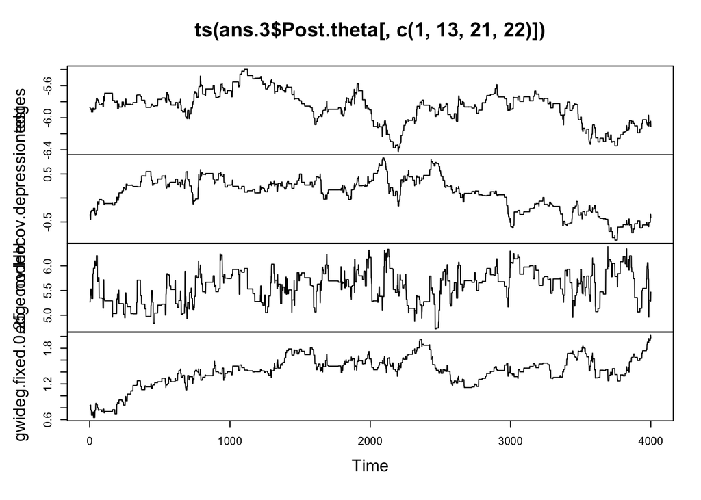

```r
plot(ts(ans.3$Post.theta[,c(1,13,21,22)]))# edges, nodeocovdepression, HH, gwideg
```

Do we get different results?

```r
creatTab(ans.3$Post.theta, thinning = 20, burnin=500)
```

```
##                           effect   mean    sd CI 0.025 CI 0.975
## 1                          edges -5.864 0.213   -6.300   -5.487
## 2                         mutual  0.518 0.589   -0.508    1.671
## 3               nodeicov.sextest  0.050 0.133   -0.183    0.263
## 4               nodeocov.sextest  0.376 0.097    0.229    0.576
## 5              nodematch.sextest  0.565 0.136    0.167    0.731
## 6               nodeicov.agetest -1.191 0.315   -1.727   -0.559
## 7               nodeocov.agetest  1.482 0.400    0.761    2.208
## 8                absdiff.agetest -2.012 0.323   -2.615   -1.472
## 9               nodeicov.edutest -0.530 0.160   -0.824   -0.191
## 10              nodeocov.edutest  0.056 0.094   -0.142    0.242
## 11             nodematch.edutest  0.029 0.077   -0.120    0.165
## 12       nodeicov.depressiontest -0.106 0.343   -0.657    0.690
## 13       nodeocov.depressiontest  0.083 0.351   -0.620    0.645
## 14        absdiff.depressiontest -0.106 0.361   -0.768    0.522
## 15              nodeicov.anxious  0.506 0.208    0.128    0.874
## 16              nodeocov.anxious  0.944 0.272    0.295    1.418
## 17               absdiff.anxious -1.612 0.357   -2.074   -0.516
## 18             nodeicov.avoidant  0.250 0.253   -0.179    0.856
## 19             nodeocov.avoidant -0.662 0.351   -1.599   -0.190
## 20              absdiff.avoidant -0.786 0.344   -1.406   -0.190
## 21                    edgecov.HH  5.647 0.299    5.053    6.171
## 22             gwideg.fixed.0.25  1.483 0.174    1.159    1.850
## 23             gwodeg.fixed.0.25 -1.178 0.220   -1.721   -0.803
## 24 gwesp.fixed.0.693147180559945  0.733 0.265    0.303    1.379
```

### Pasting the results together

To pool the estimates we can simply paste the parameters together, by stacking the rows on top of each other

```r
ThetaPool <- rbind(ans.2$Post.theta, ans.3$Post.theta)
```

Ploting the paramters, you may notice the seam where the two outputs have been stiched together.

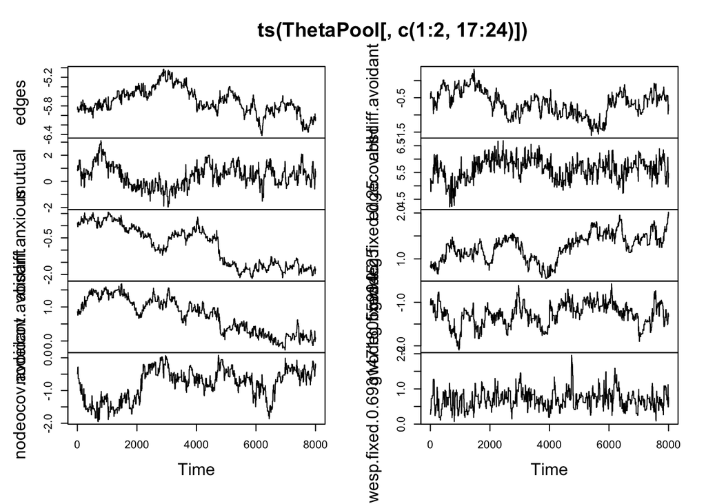

```r
plot(ts(ThetaPool[,c(1:2,17:24)]))# note this is only a subset of paramters
```

It might be an idea to take burnin and thinning into account already when pasting toghether the output.

```r
burning <- 500
thinning <- 30
N <-nrow(ans.2$Post.theta)
pickvals <- seq(burning , N, by = thinning)
ThetaPool <- rbind(ans.2$Post.theta[pickvals,], ans.3$Post.theta[pickvals,])
```

The summary of the pooled results is given by the same procedure as before (thining ang burnin allready accounted for)

```r
creatTab(ThetaPool, thinning = 1, burnin=1)
```

```
##                           effect   mean    sd CI 0.025 CI 0.975
## 1                          edges -5.683 0.276   -6.268   -5.153
## 2                         mutual  0.353 0.839   -1.096    2.175
## 3               nodeicov.sextest  0.154 0.164   -0.160    0.480
## 4               nodeocov.sextest  0.253 0.169   -0.060    0.553
## 5              nodematch.sextest  0.309 0.278   -0.086    0.709
## 6               nodeicov.agetest -1.095 0.356   -1.700   -0.283
## 7               nodeocov.agetest  1.403 0.375    0.646    2.202
## 8                absdiff.agetest -2.164 0.357   -2.896   -1.522
## 9               nodeicov.edutest -0.297 0.268   -0.774    0.129
## 10              nodeocov.edutest  0.006 0.118   -0.275    0.208
## 11             nodematch.edutest  0.008 0.086   -0.162    0.165
## 12       nodeicov.depressiontest  0.140 0.471   -0.625    1.116
## 13       nodeocov.depressiontest  0.130 0.297   -0.561    0.542
## 14        absdiff.depressiontest -0.375 0.438   -1.346    0.457
## 15              nodeicov.anxious  0.094 0.475   -0.788    0.821
## 16              nodeocov.anxious  1.022 0.281    0.343    1.536
## 17               absdiff.anxious -0.929 0.792   -2.032    0.359
## 18             nodeicov.avoidant  0.707 0.528   -0.113    1.512
## 19             nodeocov.avoidant -0.785 0.474   -1.718   -0.086
## 20              absdiff.avoidant -0.663 0.361   -1.406   -0.005
## 21                    edgecov.HH  5.665 0.404    4.743    6.321
## 22             gwideg.fixed.0.25  1.309 0.268    0.707    1.758
## 23             gwodeg.fixed.0.25 -1.295 0.264   -1.837   -0.788
## 24 gwesp.fixed.0.693147180559945  0.720 0.246    0.266    1.238
```

### Pasting networks together

Joining together the predicted and imputed networks to a joint GOF and imputation distribution follow the same procedure. There is no avaialble routine for pasting together lists in an elegant way.

```r
Nets <- list()
Nets$aux.nets <- list()
Nets$mix.nets <- list()
put.here <- 1
for (i in c(1:length(ans.2$aux.nets))){
Nets$aux.nets[[ put.here ]] <- ans.2$aux.nets[[i]]
put.here <- put.here+1
}
for (i in c(1:length(ans.3$aux.nets))){
Nets$aux.nets[[ put.here ]] <- ans.3$aux.nets[[i]]
put.here <- put.here+1
}

put.here <- 1
for (i in c(1:length(ans.2$mix.nets))){
Nets$mix.nets[[ put.here ]] <- ans.2$mix.nets[[i]]
put.here <- put.here+1
}
for (i in c(1:length(ans.3$mix.nets))){
Nets$mix.nets[[ put.here ]] <- ans.3$mix.nets[[i]]
put.here <- put.here+1
}
```

#### Check the overal goodness of fit

The GOF distributions for degree are given by

```r
gofdegs <- gof.degree(Nets)
```

A plot function superimposes the imputed and precicted

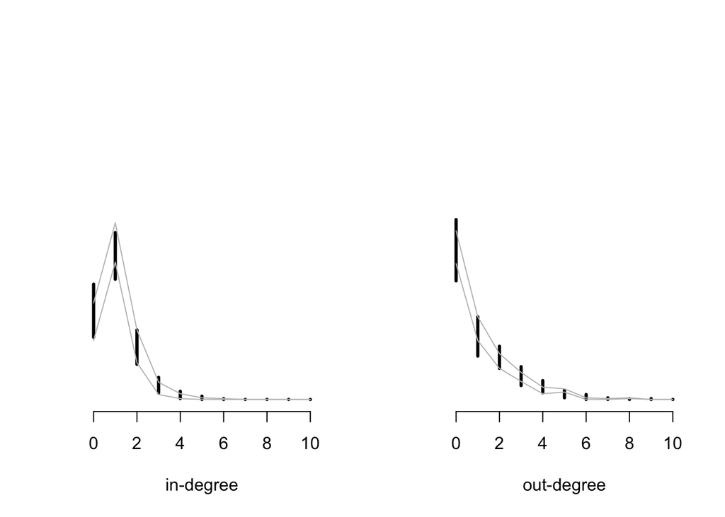

```r
plot.gof.degree(gofdegs,max.deg.plot.ind = 11)
```

If you have saved a large number of networks, calculating GOF statistics will take some time, in which case it is a good idea to thin the sample of networks when you construct `Nets`.

## A complete amalysis

To perform a complete analysis, these steps should be undertaken

| step | key function | purpose |
| --- | --- | --- |
| Setup |  | read in the raw data and format it |
| 1. | `mice` | impute attribute matrix using approaches a through d |
| 2. | `network` | format network data and imputed attributes |
| 3. | `miss_ERGM_Bayes` | run analysis |
| End |  | produce results tables and GOF |

Step 1 obviously only needs to be done once (for each configuration of types of imputed values). With a prepared imputed attribute matrix, we can look over 2 and 3, and combine results in the end.

# References

Butts, Carter T. 2015. https://CRAN.R-project.org/package=network.

———. 2016. https://CRAN.R-project.org/package=sna.

Holland, P. W., and S. Leinhardt. 1972. “Local Structure in Social Networks.” In *Sociological Methodology*, edited by Heise D., 2:1–45. 5th Ser. San Francisco, CAn: Jossey-Bass.

Koskinen, Johan H, Garry L Robins, and Philippa E Pattison. 2010. “Analysing Exponential Random Graph (P-Star) Models with Missing Data Using Bayesian Data Augmentation.” *Statistical Methodology* 7 (3). Elsevier: 366–84.

Koskinen, Johan H, Garry L Robins, Peng Wang, and Philippa E Pattison. 2013. “Bayesian Analysis for Partially Observed Network Data, Missing Ties, Attributes and Actors.” *Social Networks* 35 (4). Elsevier: 514–27.

Stys, Patrycja, Judith Verweijen, Papy Muzuri, Samuel Muhindo, Christoph Vogel, and Johan H Koskinen. 2020. “Brokering Between (Not so) Overt and (Not so) Covert Networks in Conflict Zones.” *Global Crime* 21 (1). Taylor & Francis: 74–110.

Van Buuren, Stef. 2018. *Flexible Imputation of Missing Data*. CRC press.